# Tutorial para extraer secuencias de la base de datos de BLAST

2023-06-05

## Introducción

Con frecuencia queremos realizar un alineamiento múltiple con los resultados de una búsqueda con BLAST. Pero los ejecutables de BLAST no ofrecen los “hits” en formato FASTA. Una posible solución es extraer las secuencias encontradas directamente de la base de datos. Para ello, podemos usar el ejecutable `blastdbcmd`, que acompaña a los demás ejecutables de BLAST.

## BLAST

Como *query* usaré la proteína Q5TIW8 de *Secale cereale*:

```r
library('Biostrings')
library('kableExtra')
download.file('https://rest.uniprot.org/uniprotkb/Q5TIW8.fasta', 'Q5TIW8.fasta')
system2('blastp',
        args = c('-db', 'swissprot',
                 '-query', 'Q5TIW8.fasta',
                 '-out', 'Q5TIW8_hits.txt',
                 '-evalue', '1.0e-100',
                 '-outfmt', '7'))
hits <- read.table('Q5TIW8_hits.txt',
                   col.names = c('query', 'subject', 'identity', 'al.length',
                                 'mismatches', 'gaps', 'qstart', 'qend',
                                 'sstart', 'send', 'evalue', 'bitscore'))
hits$query <- substr(hits$query, 4, 9)
hits$evalue <- as.character(signif(hits$evalue, digits = 3))
kable(head(hits), align = 'llrrrrrrrrrr') %>% kable_styling()
```

| query | subject | identity | al.length | mismatches | gaps | qstart | qend | sstart | send | evalue | bitscore |
| --- | --- | --- | --- | --- | --- | --- | --- | --- | --- | --- | --- |
| Q5TIW8 | Q5QJ60.1 | 69.884 | 518 | 151 | 2 | 3 | 515 | 5 | 522 | 0 | 744 |
| Q5TIW8 | F1BVB6.1 | 44.444 | 504 | 253 | 9 | 31 | 514 | 32 | 528 | 2.88e-156 | 458 |
| Q5TIW8 | Q9FI25.1 | 43.810 | 525 | 275 | 8 | 5 | 512 | 6 | 527 | 1.4e-142 | 424 |
| Q5TIW8 | Q9FKU8.1 | 41.729 | 532 | 285 | 11 | 5 | 515 | 10 | 537 | 2.43e-142 | 423 |
| Q5TIW8 | Q9SVG5.1 | 42.966 | 526 | 278 | 10 | 5 | 514 | 7 | 526 | 3.77e-142 | 422 |
| Q5TIW8 | Q9FI21.1 | 43.575 | 537 | 276 | 12 | 1 | 517 | 2 | 531 | 9.36e-142 | 421 |

## FASTA

Podemos crear un archivo FASTA con las proteínas encontradas en el BLAST:

```r
system2('blastdbcmd',
        args = c('-db', 'swissprot',
                 '-entry', paste(hits$subject, collapse = ','),
                 '-out', 'Q5TIW8_hits.fa'))
```

Y leer el archivo:

```r
FullNotAligned <- readAAStringSet('Q5TIW8_hits.fa')
names(FullNotAligned[1])
```

```
## [1] "Q5QJ60.1 RecName: Full=Berberine bridge enzyme-like Cyn d 4; AltName: Full=60 kDa pollen antigen; Short=BG60; AltName: Full=Cyn d BG60; AltName: Full=FAD-linked oxidoreductase BG60; AltName: Full=Pollen isoallergen BG60; AltName: Allergen=Cyn d 4; Flags: Precursor [Cynodon dactylon]"
```

```r
# Sustituyo los nombres por sólo la primera palabra de cada nombre:
names(FullNotAligned) <- sapply(strsplit(names(FullNotAligned), ' '), '[', 1)
names(FullNotAligned[1])
```

```
## [1] "Q5QJ60.1"
```

Podemos intentar alinear las secuencias completas. Pero en la tabla `hits` tenemos información de dónde empieza y dónde termina la homología con la *query* en cada secuencia encontrada: en los campos `sstart` y `send`. El reto está en recortar cada secuencia en `FullNotAligned` en los puntos indicados en `hits$sstart` y `hits$send`. Para hacerlo todo de una vez y evitar tener que usar un *loop*, deberíamos emplear la función `mapply()`, pero me daba un error que no he podido resolver. Así que opto por un *loop*.

```r
# Comprobamos que el orden de las secuencias en FullNotAligned coincide con el
# orden de los hits en el resultado del BLAST:
stopifnot(all.equal(names(FullNotAligned), hits$subject))

NotAligned <- AAStringSet()
for (i in 1:length(FullNotAligned)) {
   NotAligned <- append(NotAligned, subseq(FullNotAligned[i], hits[i, 'sstart'], hits[i, 'send']))
}
```

Podemos comprobar que el conjunto de secuencias `NotAligned` son en general más cortas que las de `FullNotAligned`. Y además sus longitudes coinciden con las zonas alineadas por el BLAST:

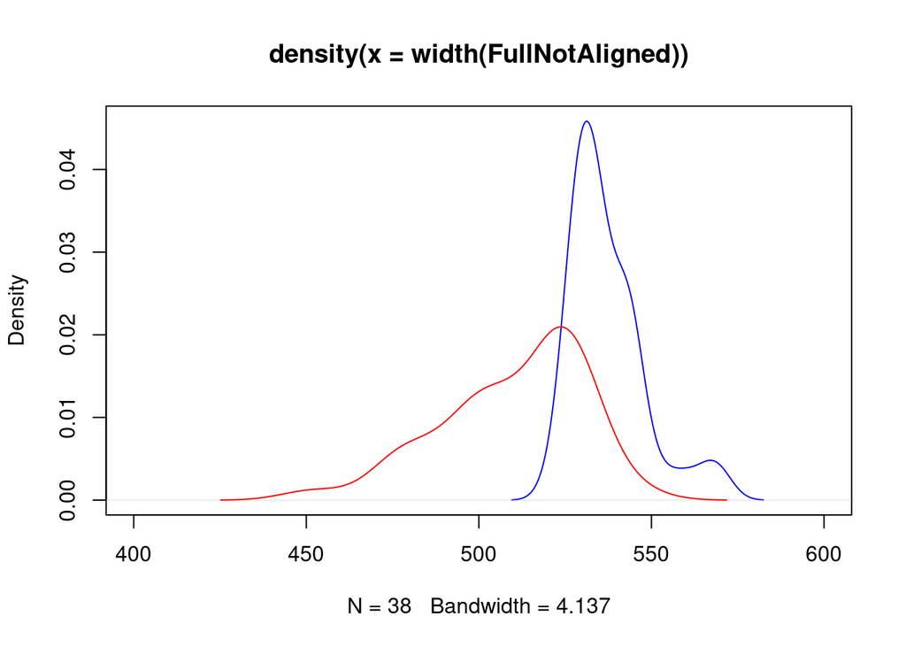

```r
stopifnot(all.equal(width(NotAligned), hits$send - hits$sstart + 1))
plot(density(width(FullNotAligned)), col = 'blue', xlim = c(400,600))
lines(density(width(NotAligned)), col = 'red')
```

## Alineamiento

Bueno, a partir de aquí es fácil realizar el alineamiento con la función `AlignSeqs()` de `DECIPHER`.